# HW2

Nicole Higgins

2023-02-07

### Q0 Collaborators

Who did you work with on this assignment? You’ll get a bonus 5 points if you name someone and they name you. *No scores above 100% are allowed, but these bonus points can repair mistakes on this assignment*.

**I worked with Jonny**

### Q1 Some flop counts

Let $A$ be a $1000\times1000$ matrix and let $x\in\mathbb{R}^{1000}$.

- How many flops (additions and multiplications of real numbers) are required to compute the inner product $x^Tx$?

**1999 flops**

- How many flops are required to compute the matrix-vector product $Ax$?

**1,999,000 flops**

- How many flops are required to compute the matrix-matrix product $AA$?

**1,999,000,000 flops**

- Suppose $B$ is a rank-one matrix, $B=uv^T$ where $u,v\in\mathbb{R}^{1000}$. To form $Bx$ cheaply we should do $u(v^Tx)$ instead of $(uv^T)x$. How many flops are needed?

**2,999 flops**

### Q2 Eigenvalues of a real, symmetric matrix

- Let $w = \begin{pmatrix}2+3i\\4-i\\-10i\end{pmatrix}\in\mathbb{C}^2.$ Find $w^*w$ where $w^*$ is the result of taking the transpose and then also changing the sign of the imaginary parts (for example, changing $10+5i$ into $10-5i$). The $*$ operation is called the “Hermitian transpose” and it has the same rules as the ordinary transpose: $(AB)^* = B^*A^*$, $(A+B)^* = A^*+B^*$ and so on.

**130**

- Explain why $x^*x$ is real for any $x\in\mathbb{C}^n$.

**$x^*x$ is real for any $x\in\mathbb{C}^n$ because the product of two opposite imaginary binomials will result in a canceling out of the singular i’s and any resulting $i^2* are equal to $-1$, so the product is always real.**

- Suppose that $A$ is an $n\times n$ matrix with real or complex entries and that $x$ is a vector in $\mathbb{R}^n$ or $\mathbb{C}^n$. Is $x^*Ax$ a number, vector, or matrix?

**a number because [1 x n][n x n][n x 1] will result in a [1 x 1]**

- Suppose $A=A^*$ (this includes the case where $A$ is real and symmetric). Suppose that $Ax = \lambda x$ for some nonzero $x$. That is, $x$ is an eigenvector of $A$ with eigenvalue $\lambda$. Show that $x^*Ax = (x^*Ax)^*$, which proves that $x^*Ax$ is real. Then show that $x^*Ax = \lambda x^*x$. Explain why this means that $\lambda$ must be a real number.

**First, given $A=A^*$, we know $x^*Ax=x^*A^*x$ and since a transposed transpose reverts a matrix to its original form, we then know $x^*AX=x^*A^*(x^*)^*$. Given transpose product rules, we then know $x^*Ax=(x^*Ax)^*$.**

**Next, given $Ax= \lambda x$, we know $x^*Ax=x^* \lambda x$ which equals $\lambda x^*x$ since $\lambda$ is a scalar.**

**These results prove that $\lambda$ is real since by isolating it in the final equality, we see that $\lambda = x^*Ax/(x^*x)$ and since both the numerator and denominator here are real, $\lambda$ must be as well.**

- Form the matrices $P$ and $S$ in R and use the syntax *eigen(A)$values* to find their eigenvalues. (According to the result we proved, $S$ should have real eigenvalues and $P$ might or might not have real eigenvalues).
  $$P =
  \begin{pmatrix} -4&5&6\\1&0&9
  \\9&1&2\end{pmatrix}
  \qquad
  S = \begin{pmatrix}
  -1&2&1\\2&7&-3\\1&-3&4\end{pmatrix}$$

```r
pData = c(-4,1,9,5,0,1,6,9,2)
sData = c(-1,2,1,2,7,-3,1,-3,4)

P = matrix(pData, 3, 3)
S = matrix(sData, 3, 3)

print(P)
```

```
##      [,1] [,2] [,3]
## [1,]   -4    5    6
## [2,]    1    0    9
## [3,]    9    1    2
```

```r
print(S)
```

```
##      [,1] [,2] [,3]
## [1,]   -1    2    1
## [2,]    2    7   -3
## [3,]    1   -3    4
```

```r
eigen(P)$values
```

```
## [1]  9.988621+0.000000i -5.994310+2.796074i -5.994310-2.796074i
```

```r
eigen(S)$values
```

```
## [1]  9  3 -2
```

### Q3 Underdetermined system

Let’s consider a case with one equation and three unknowns:
$$3x + 5y + 6z = 210.$$

1. Find the smallest solution as measured in the two-norm. *Hint: you are finding the shortest distance from the origin to a plane. One approach is to use Lagrange multipliers to minimize $x^2+y^2+z^2$, with the equation above acting as the constraint.*

**[9, 15, 18]**

2. Find the smallest solution as measured in the one-norm.

**[0, 0, 35]**

3. Find the smallest solution as measured in the max-norm.

4. Do a web search for “one-norm minimization.” You should quickly learn that $\ell^1$ minimization has become important in the last 20 years because of its tendency to produce *sparse solutions.* What does that mean? Did this happen in part (b) for you?

**Sparse means more than half the entries are zero. This happened in part (b) since two of the three entries are zero.**

### Q4 Not a norm

We said that the $p$-norm requires $p\in(1,\infty)$. Here we’ll see what goes wrong if we try $p=\frac12$. That would lead to
$$\|x\|_{1/2} =
\left(\sqrt{|x_1|} + \sqrt{|x_2|}+\cdots
+\sqrt{|x_n|}\right)^2.$$

1. Find $\|x\|_{1/2}$ if $x^T = (100\;\;\;-25\;\;\;16\;\;\;0)$.

**361**

2. Find an example in $\mathbb{R}^3$ where the triangle inequality fails. That is, give vectors $v,w\in\mathbb{R}^3$ such that $\|v+w\|_{1/2} > \|v\|_{1/2} + \|w\|_{1/2}$. Your example should have nice enough numbers that you can do this on paper, without calculator / R help.

**v = [1,1,0], w = [0, 0, 1]**

### Q5 Trapezoid rule with user-specified tolerance

Write an R function that carries out trapezoidal rule integration to a specified error tolerance:

**I first drew a diagram of what the function would be doing. Then I wrote some pseudo-code to better understand the order of the function. Finally, I worked with Jonny to translate the writing into code.**

```r
my.trapezoid <- function(f, a, b, tol=1e-6){
  #initial amt of measurements
  n <- 4
  #initialize tolerance to 1
  tolerance <- 1
  actual <- integrate(f,a,b)
  #while tolerance is higher than our threshold, compute integral with 2n measurements
  while (tolerance > tol){
    #find integral with trap method
    x <- seq(a,b,length = n)
    y <- f(x)
    h <- (b-a) / (n-1)
    area <- (h * sum(y[1:(n-1)]) / 2) + (h * sum(y[2:n]) / 2)
    #calculates and updates tolerance
    tolerance <- abs(area - actual$value)/actual$value
    error <- abs(area-actual$value)
    #set n to 2n
    n <- n*2
  }
  return(c(area,error))
}
```

Finally, demonstrate your function by solving these three integrals to accuracy $10^{-4}$. As a check, the exact value of $I$ is $1.0$.
$$I = \int_0^{100} \frac{3\sqrt{w}}{2000}\,dw,\qquad
J = \int_2^5 \exp((x-3)(x-4))\,dx,\qquad K = \int_{-\pi}^{\pi}
\frac{\cos^2(3t+1)}{1.05 + \sin(t)}\,dt.$$

```r
#formulas
fi <- function(x) {
  return((3*sqrt(x))/2000)
}
fj <- function(x) {
  return(exp((x-3)*(x-4)))
}
fk <- function(x) {
  return((cos(3*x+1)^2)/(1.05 + sin(x)))
}

sprintf("%.15f",my.trapezoid(fi, 0, 100))
```

```
## [1] "0.999999580290568" "0.000000531960950"
```

```r
sprintf("%.15f",my.trapezoid(fj, 2,5))
```

```
## [1] "6.328714803997001" "0.000001982867102"
```

```r
sprintf("%.15f",my.trapezoid(fk, -pi, pi))
```

```
## [1] "10.429870111561614" "0.000000139355880"
```

### Q6 The trapezoid rule is spectrally accurate for periodic problems

Explore how the error of the trapezoid rule depends on the number of nodes for the integrals $J$ and $K$ in the previous question. To do this, make a loglog plot with $n$ (number of quadrature nodes or function measurements) on the horizontal axis and $E$ (the absolute value of the difference between the true integral and the trapezoid rule estimate) on the vertical axis.

```r
#same function, but only find the error of one trap calculation for a specific n
my.trapezoid2 <- function(f, a, b, n){
  area <- 0
  actual <- integrate(f,a,b)
  x <- seq(a,b,length = n)
  y <- f(x)
  h <- (b-a) / (n-1)
  area <- (h * sum(y[1:(n-1)]) / 2) + (h * sum(y[2:n]) / 2)
  error <- abs(area-actual$value)
  return(error)
}
```

```r
nlist = c(2,4,10,100,200,500,1000,2500,5000)
i = 1
errors = 0
for(n in nlist){
  errors[i] = my.trapezoid2(fj,2,5,n)
  i = i + 1
}
i = 1
errors.1 = 0
for(n in nlist){
  errors.1[i] = my.trapezoid2(fk,-pi,pi,n)
  i = i + 1
}
```

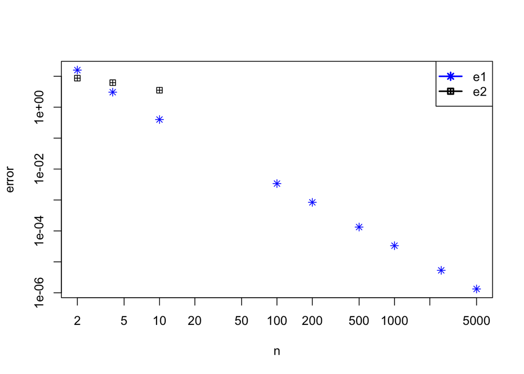

```r
x <- nlist
plot(x,errors,type='p',log='xy',col="blue",pch=8,xlab="n",ylab="error")
lines(x,errors.1,type='p',pch=12)
legend("topright",legend=c("e1","e2"),pch=c(8,12),lwd=2,col=c("blue","black"))
```

### Q7 Secant

Implement the secant method and use it to find a value of $x$ where $\cosh(x) = \sinh(x) + 0.1$. Give at least twelve correct digits. Explain how you pick the two initial guesses.

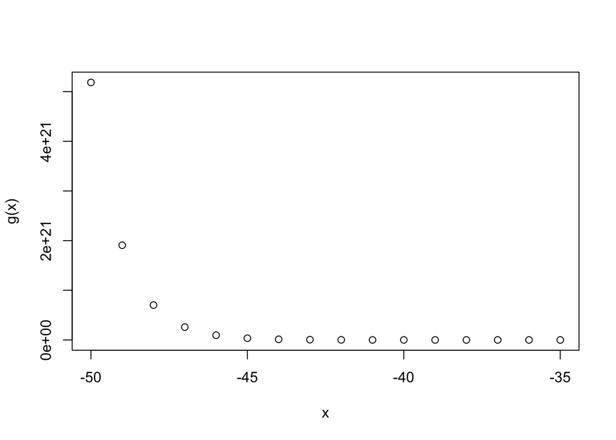

```r
g <- function(x) {
  return(cosh(x) - sinh(x) - 0.1)
}

x <- -50:-35
plot(x, g(x))
```

```r
secant <- function(func, x0, x1, tol = 1e-12){
  f <- func
  x2 <- x1 - f(x1) * (x1 - x0) / (f(x1) - f(x0))
  iteration <- 2
  while (abs(x2 - x1) > tol) {
    x0 <- x1
    x1 <- x2
    x2 <- x1 - f(x1) * (x1 - x0) / (f(x1) - f(x0))
    iteration <- iteration + 1
  }
  return(x2)
}

sprintf("%.15f", secant (g, 2.2, 2.4))
```

```
## [1] "2.302585092994045"
```

### Q8 Five simple versions of $Ax=b$

In each of the five cases, find the vector $x$ which solves the problem $Ax=b$. Do it by hand. Missing entries are zeros. It is OK to not show work, but please write at least one sentence describing your method in each case. It is OK to write on paper and scan/photograph your answers as long as you turn in a single PDF as your solution.

```r
library("magick")
```

[output not shown]

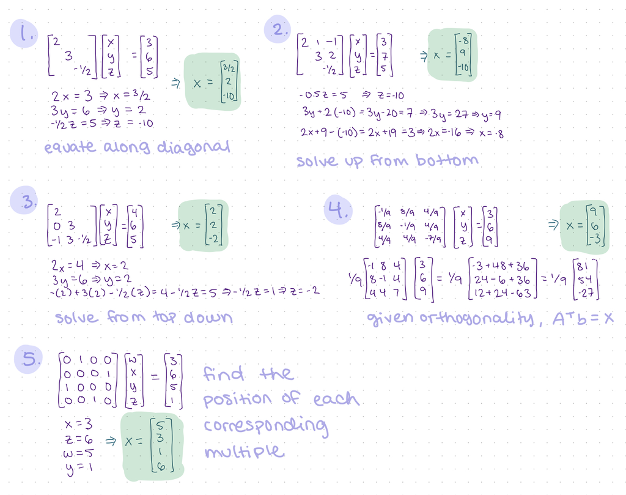

```r
work = image_read("hw2q8.png")
print(work)
```

**thank you!**